# Home Credit Default Risk EDA

Dheeraj Yata

2024-02-18

## Introduction

Home Credit Group is dedicated to expanding financial inclusion by utilizing alternative data sources to assess repayment abilities for underserved populations. Leveraging diverse datasets, including telco and transactional information, Home Credit seeks to ensure equitable access to credit and facilitate successful loan repayment. Through innovative data-driven approaches, Home Credit aims to enhance risk assessment practices and promote responsible lending. This initiative underscores the importance of leveraging advanced analytics to mitigate risk and empower individuals financially. By harnessing predictive modeling techniques, Home Credit strives to provide a positive borrowing experience for all clients.

## Project goal

The project goal would be to develop predictive models for credit risk assessment using the provided dataset, which includes various features such as telco and transactional information. These models aim to accurately predict the repayment abilities of Home Credit’s clients, thereby enabling informed lending decisions. The ultimate objective is to enhance Home Credit’s credit assessment capabilities, minimize default risk, and ensure fair and equitable access to credit for underserved populations. By achieving this goal, Home Credit seeks to provide a positive borrowing experience for its clients while promoting financial inclusion and empowerment.

```r
#load the libraries
library(tidyverse)
library(dplyr)
library(rpart)
library(rpart.plot)
library(skimr)
library(recipes)
library(h2o)
library(tictoc)
```

## Download and inspect data

```r
#load required data
test_HC <- read_csv("application_test.csv")
train_HC <- read_csv("application_train.csv")
```

```r
#display top most rows of the data.
head(train_HC)
```

```
## # A tibble: 6 × 122
##   SK_ID_CURR TARGET NAME_CONTRACT_TYPE CODE_GENDER FLAG_OWN_CAR FLAG_OWN_REALTY
##        <dbl>  <dbl> <chr>              <chr>       <chr>        <chr>
## 1     100002      1 Cash loans         M           N            Y
## 2     100003      0 Cash loans         F           N            N
## 3     100004      0 Revolving loans    M           Y            Y
## 4     100006      0 Cash loans         F           N            Y
## 5     100007      0 Cash loans         M           N            Y
## 6     100008      0 Cash loans         M           N            Y
## # ℹ 116 more variables: CNT_CHILDREN <dbl>, AMT_INCOME_TOTAL <dbl>,
## #   AMT_CREDIT <dbl>, AMT_ANNUITY <dbl>, AMT_GOODS_PRICE <dbl>,
## #   NAME_TYPE_SUITE <chr>, NAME_INCOME_TYPE <chr>, NAME_EDUCATION_TYPE <chr>,
## #   NAME_FAMILY_STATUS <chr>, NAME_HOUSING_TYPE <chr>,
## #   REGION_POPULATION_RELATIVE <dbl>, DAYS_BIRTH <dbl>, DAYS_EMPLOYED <dbl>,
## #   DAYS_REGISTRATION <dbl>, DAYS_ID_PUBLISH <dbl>, OWN_CAR_AGE <dbl>,
## #   FLAG_MOBIL <dbl>, FLAG_EMP_PHONE <dbl>, FLAG_WORK_PHONE <dbl>, …
```

```r
head(test_HC)
```

```
## # A tibble: 6 × 121
##   SK_ID_CURR NAME_CONTRACT_TYPE CODE_GENDER FLAG_OWN_CAR FLAG_OWN_REALTY
##        <dbl> <chr>              <chr>       <chr>        <chr>
## 1     100001 Cash loans         F           N            Y
## 2     100005 Cash loans         M           N            Y
## 3     100013 Cash loans         M           Y            Y
## 4     100028 Cash loans         F           N            Y
## 5     100038 Cash loans         M           Y            N
## 6     100042 Cash loans         F           Y            Y
## # ℹ 116 more variables: CNT_CHILDREN <dbl>, AMT_INCOME_TOTAL <dbl>,
## #   AMT_CREDIT <dbl>, AMT_ANNUITY <dbl>, AMT_GOODS_PRICE <dbl>,
## #   NAME_TYPE_SUITE <chr>, NAME_INCOME_TYPE <chr>, NAME_EDUCATION_TYPE <chr>,
## #   NAME_FAMILY_STATUS <chr>, NAME_HOUSING_TYPE <chr>,
## #   REGION_POPULATION_RELATIVE <dbl>, DAYS_BIRTH <dbl>, DAYS_EMPLOYED <dbl>,
## #   DAYS_REGISTRATION <dbl>, DAYS_ID_PUBLISH <dbl>, OWN_CAR_AGE <dbl>,
## #   FLAG_MOBIL <dbl>, FLAG_EMP_PHONE <dbl>, FLAG_WORK_PHONE <dbl>, …
```

```r
# shape of the dataset
num_rows <- nrow(train_HC)
num_cols <- ncol(train_HC)

print(num_rows)  # Number of rows
```

```
## [1] 307511
```

```r
print(num_cols)  # Number of columns
```

```
## [1] 122
```

## Correlations

```r
if ("TARGET" %in% colnames(train_HC)) {
  # Select only numeric columns
  numeric_cols <- sapply(train_HC, is.numeric)

  # Exclude the 'TARGET' variable from numeric columns
  numeric_cols <- numeric_cols & colnames(train_HC) != "TARGET"

  # Compute the correlation between TARGET variable and all other numeric variables
  correlation_with_target <- cor(train_HC[, numeric_cols], train_HC$TARGET, use = "pairwise.complete.obs")

  # Print the correlation with the target variable
  print(correlation_with_target)

  # Extract correlation values for TARGET variable
  correlation_with_target <- abs(correlation_with_target)

  # Sort correlation values in descending order
  sorted_correlation <- sort(correlation_with_target, decreasing = TRUE)

  # Top predictors based on correlation
  top_predictors <- names(sorted_correlation)

  # Display top predictors
  top_predictors
} else {
  print("Target variable 'TARGET' not found in the dataset.")
}
```

```
##                                       [,1]
## SK_ID_CURR                   -0.0021084690
## CNT_CHILDREN                  0.0191871336
## AMT_INCOME_TOTAL             -0.0039818656
## AMT_CREDIT                   -0.0303692865
## AMT_ANNUITY                  -0.0128165615
## AMT_GOODS_PRICE              -0.0396452812
## REGION_POPULATION_RELATIVE   -0.0372271485
## DAYS_BIRTH                    0.0782393083
## DAYS_EMPLOYED                -0.0449316627
## DAYS_REGISTRATION             0.0419748628
## DAYS_ID_PUBLISH               0.0514571726
## OWN_CAR_AGE                   0.0376115643
## FLAG_MOBIL                    0.0005343956
## FLAG_EMP_PHONE                0.0459822197
## FLAG_WORK_PHONE               0.0285243224
## FLAG_CONT_MOBILE              0.0003701268
## FLAG_PHONE                   -0.0238062723
## FLAG_EMAIL                   -0.0017583834
## CNT_FAM_MEMBERS               0.0093077844
## REGION_RATING_CLIENT          0.0588990149
## REGION_RATING_CLIENT_W_CITY   0.0608926676
## HOUR_APPR_PROCESS_START      -0.0241658314
## REG_REGION_NOT_LIVE_REGION    0.0055759445
## REG_REGION_NOT_WORK_REGION    0.0069419075
## LIVE_REGION_NOT_WORK_REGION   0.0028194792
## REG_CITY_NOT_LIVE_CITY        0.0443953748
## REG_CITY_NOT_WORK_CITY        0.0509944644
## LIVE_CITY_NOT_WORK_CITY       0.0325183411
## EXT_SOURCE_1                 -0.1553171261
## EXT_SOURCE_2                 -0.1604716716
## EXT_SOURCE_3                 -0.1789186976
## APARTMENTS_AVG               -0.0294975646
## BASEMENTAREA_AVG             -0.0227457432
## YEARS_BEGINEXPLUATATION_AVG  -0.0097276733
## YEARS_BUILD_AVG              -0.0221492841
## COMMONAREA_AVG               -0.0185496616
## ELEVATORS_AVG                -0.0341987937
## ENTRANCES_AVG                -0.0191721820
## FLOORSMAX_AVG                -0.0440033705
```

[output cut: 51 more lines]

```
## FLAG_DOCUMENT_13             -0.0115832223
## FLAG_DOCUMENT_14             -0.0094638219
## FLAG_DOCUMENT_15             -0.0065356576
## FLAG_DOCUMENT_16             -0.0116146716
## FLAG_DOCUMENT_17             -0.0033775691
## FLAG_DOCUMENT_18             -0.0079523851
## FLAG_DOCUMENT_19             -0.0013575183
## FLAG_DOCUMENT_20              0.0002153936
## FLAG_DOCUMENT_21              0.0037086250
## AMT_REQ_CREDIT_BUREAU_HOUR    0.0009304246
## AMT_REQ_CREDIT_BUREAU_DAY     0.0027044014
## AMT_REQ_CREDIT_BUREAU_WEEK    0.0007877117
## AMT_REQ_CREDIT_BUREAU_MON    -0.0124624192
## AMT_REQ_CREDIT_BUREAU_QRT    -0.0020219274
## AMT_REQ_CREDIT_BUREAU_YEAR    0.0199298586
```

Top Five Predictors with Positive Correlation: DAYS_BIRTH: 0.0782393083 DAYS_ID_PUBLISH: 0.0514571726 REGION_RATING_CLIENT_W_CITY: 0.0608926676 REGION_RATING_CLIENT: 0.0588990149 DAYS_LAST_PHONE_CHANGE: 0.0552184835

EXT_SOURCE_1, EXT_SOURCE_2, and EXT_SOURCE_3 have negative correlation coefficients, indicating that as these external scores increase, there’s a tendency for the TARGET variable to decrease (meaning a lower chance of default).

## Summary table

```r
train_HC <- read_csv("application_train.csv")  %>% mutate(TARGET = factor(TARGET))

summary(train_HC)
```

```
##    SK_ID_CURR     TARGET     NAME_CONTRACT_TYPE CODE_GENDER
##  Min.   :100002   0:282686   Length:307511      Length:307511
##  1st Qu.:189146   1: 24825   Class :character   Class :character
##  Median :278202              Mode  :character   Mode  :character
##  Mean   :278180
##  3rd Qu.:367142
##  Max.   :456255
##
##  FLAG_OWN_CAR       FLAG_OWN_REALTY     CNT_CHILDREN     AMT_INCOME_TOTAL
##  Length:307511      Length:307511      Min.   : 0.0000   Min.   :    25650
##  Class :character   Class :character   1st Qu.: 0.0000   1st Qu.:   112500
##  Mode  :character   Mode  :character   Median : 0.0000   Median :   147150
##                                        Mean   : 0.4171   Mean   :   168798
##                                        3rd Qu.: 1.0000   3rd Qu.:   202500
##                                        Max.   :19.0000   Max.   :117000000
##
##    AMT_CREDIT       AMT_ANNUITY     AMT_GOODS_PRICE   NAME_TYPE_SUITE
##  Min.   :  45000   Min.   :  1616   Min.   :  40500   Length:307511
##  1st Qu.: 270000   1st Qu.: 16524   1st Qu.: 238500   Class :character
##  Median : 513531   Median : 24903   Median : 450000   Mode  :character
##  Mean   : 599026   Mean   : 27109   Mean   : 538396
##  3rd Qu.: 808650   3rd Qu.: 34596   3rd Qu.: 679500
##  Max.   :4050000   Max.   :258026   Max.   :4050000
##                    NA's   :12       NA's   :278
##  NAME_INCOME_TYPE   NAME_EDUCATION_TYPE NAME_FAMILY_STATUS NAME_HOUSING_TYPE
##  Length:307511      Length:307511       Length:307511      Length:307511
##  Class :character   Class :character    Class :character   Class :character
##  Mode  :character   Mode  :character    Mode  :character   Mode  :character
##
##
##
##
##  REGION_POPULATION_RELATIVE   DAYS_BIRTH     DAYS_EMPLOYED    DAYS_REGISTRATION
##  Min.   :0.00029            Min.   :-25229   Min.   :-17912   Min.   :-24672
##  1st Qu.:0.01001            1st Qu.:-19682   1st Qu.: -2760   1st Qu.: -7480
##  Median :0.01885            Median :-15750   Median : -1213   Median : -4504
##  Mean   :0.02087            Mean   :-16037   Mean   : 63815   Mean   : -4986
##  3rd Qu.:0.02866            3rd Qu.:-12413   3rd Qu.:  -289   3rd Qu.: -2010
##  Max.   :0.07251            Max.   : -7489   Max.   :365243   Max.   :     0
##
```

[output cut: 225 more lines]

```
##  Min.   :0.00               Min.   : 0.00             Min.   :  0.00
##  1st Qu.:0.00               1st Qu.: 0.00             1st Qu.:  0.00
##  Median :0.00               Median : 0.00             Median :  0.00
##  Mean   :0.03               Mean   : 0.27             Mean   :  0.27
##  3rd Qu.:0.00               3rd Qu.: 0.00             3rd Qu.:  0.00
##  Max.   :8.00               Max.   :27.00             Max.   :261.00
##  NA's   :41519              NA's   :41519             NA's   :41519
##  AMT_REQ_CREDIT_BUREAU_YEAR
##  Min.   : 0.0
##  1st Qu.: 0.0
##  Median : 1.0
##  Mean   : 1.9
##  3rd Qu.: 3.0
##  Max.   :25.0
##  NA's   :41519
```

## Accuracy

```r
# Calculate majority classifier
train_HC %>%
  dplyr::summarize(TARGET = mean(TARGET =="0"))
```

```
## # A tibble: 1 × 1
##   TARGET
##    <dbl>
## 1  0.919
```

This code calculates the proportion of the majority class in the TARGET variable of the train_HC dataset. With a value of approximately 0.919, it indicates that about 91.9% of the observations in the TARGET variable have the value ‘0’. This suggests that the dataset is imbalanced, with the majority class (‘0’) dominating the distribution.

## Check missing data

```r
#Check whether there are missing values in the data
count_missings <- function(x) sum(is.na(x))

train_HC %>%
  summarize_all(count_missings) # Handy summarize_all function
```

```
## # A tibble: 1 × 122
##   SK_ID_CURR TARGET NAME_CONTRACT_TYPE CODE_GENDER FLAG_OWN_CAR FLAG_OWN_REALTY
##        <int>  <int>              <int>       <int>        <int>           <int>
## 1          0      0                  0           0            0               0
## # ℹ 116 more variables: CNT_CHILDREN <int>, AMT_INCOME_TOTAL <int>,
## #   AMT_CREDIT <int>, AMT_ANNUITY <int>, AMT_GOODS_PRICE <int>,
## #   NAME_TYPE_SUITE <int>, NAME_INCOME_TYPE <int>, NAME_EDUCATION_TYPE <int>,
## #   NAME_FAMILY_STATUS <int>, NAME_HOUSING_TYPE <int>,
## #   REGION_POPULATION_RELATIVE <int>, DAYS_BIRTH <int>, DAYS_EMPLOYED <int>,
## #   DAYS_REGISTRATION <int>, DAYS_ID_PUBLISH <int>, OWN_CAR_AGE <int>,
## #   FLAG_MOBIL <int>, FLAG_EMP_PHONE <int>, FLAG_WORK_PHONE <int>, …
```

There are many columns with missing values, some columns have greater than 50% NA values in this dataset.

```r
# missing percentage of NA values
missing_pctg <- train_HC %>%
    summarize_all(.funs = ~ sum(is.na(.)) / length(.)) %>%
    gather() %>%
    arrange(desc(value)) %>%
    filter(value > 0)

head(missing_pctg, n = 45)
```

```
## # A tibble: 45 × 2
##    key                      value
##    <chr>                    <dbl>
##  1 COMMONAREA_AVG           0.699
##  2 COMMONAREA_MODE          0.699
##  3 COMMONAREA_MEDI          0.699
##  4 NONLIVINGAPARTMENTS_AVG  0.694
##  5 NONLIVINGAPARTMENTS_MODE 0.694
##  6 NONLIVINGAPARTMENTS_MEDI 0.694
##  7 FONDKAPREMONT_MODE       0.684
##  8 LIVINGAPARTMENTS_AVG     0.684
##  9 LIVINGAPARTMENTS_MODE    0.684
## 10 LIVINGAPARTMENTS_MEDI    0.684
## # ℹ 35 more rows
```

```r
# Define the count_missings function
count_missings <- function(x) sum(is.na(x))


# Function to remove columns with more than 50% null values
remove_columns_with_nulls <- function(train_HC, threshold = 0.5) {
  num_rows <- nrow(train_HC)
  null_percentages <- colMeans(is.na(train_HC))
  columns_to_remove <- names(null_percentages[null_percentages > threshold])
  train_HC <- train_HC %>% dplyr::select(-one_of(columns_to_remove)) # Explicitly call dplyr::select
  return(train_HC)
}

# Remove columns with more than 50% null values
train_HC <- remove_columns_with_nulls(train_HC)

# Check missing values in the remaining columns
train_HC %>%
  summarise_all(count_missings)
```

```
## # A tibble: 1 × 81
##   SK_ID_CURR TARGET NAME_CONTRACT_TYPE CODE_GENDER FLAG_OWN_CAR FLAG_OWN_REALTY
##        <int>  <int>              <int>       <int>        <int>           <int>
## 1          0      0                  0           0            0               0
## # ℹ 75 more variables: CNT_CHILDREN <int>, AMT_INCOME_TOTAL <int>,
## #   AMT_CREDIT <int>, AMT_ANNUITY <int>, AMT_GOODS_PRICE <int>,
## #   NAME_TYPE_SUITE <int>, NAME_INCOME_TYPE <int>, NAME_EDUCATION_TYPE <int>,
## #   NAME_FAMILY_STATUS <int>, NAME_HOUSING_TYPE <int>,
## #   REGION_POPULATION_RELATIVE <int>, DAYS_BIRTH <int>, DAYS_EMPLOYED <int>,
## #   DAYS_REGISTRATION <int>, DAYS_ID_PUBLISH <int>, FLAG_MOBIL <int>,
## #   FLAG_EMP_PHONE <int>, FLAG_WORK_PHONE <int>, FLAG_CONT_MOBILE <int>, …
```

```r
# assigning a variable for all string variables
string_2_factor_names <- train_HC %>%
    select_if(is.character) %>%
    names()

string_2_factor_names
```

```
##  [1] "NAME_CONTRACT_TYPE"         "CODE_GENDER"
##  [3] "FLAG_OWN_CAR"               "FLAG_OWN_REALTY"
##  [5] "NAME_TYPE_SUITE"            "NAME_INCOME_TYPE"
##  [7] "NAME_EDUCATION_TYPE"        "NAME_FAMILY_STATUS"
##  [9] "NAME_HOUSING_TYPE"          "OCCUPATION_TYPE"
## [11] "WEEKDAY_APPR_PROCESS_START" "ORGANIZATION_TYPE"
## [13] "EMERGENCYSTATE_MODE"
```

```r
# assigning a variable for all numeric variables and numeric factor data
# I looked at which numeric data should be factored (categorical). These typically have a low number of unique levels. I used a few dplyr and purrr operations to get a count of the unique levels. The real trick is using map_df() with the anonymous function ~ unique(.) %>% length(), which counts the unique values in each column, then gather()-ing the results in the long format.
unique_numeric_values_tbl <- train_HC %>%
    select_if(is.numeric) %>%
    map_df(~ unique(.) %>% length()) %>%
    gather() %>%
    arrange(value) %>%
    mutate(key = as_factor(key))

head(unique_numeric_values_tbl)
```

```
## # A tibble: 6 × 2
##   key              value
##   <fct>            <int>
## 1 FLAG_MOBIL           2
## 2 FLAG_EMP_PHONE       2
## 3 FLAG_WORK_PHONE      2
## 4 FLAG_CONT_MOBILE     2
## 5 FLAG_PHONE           2
## 6 FLAG_EMAIL           2
```

```r
# I used a factor limit of 7 meaning any values with less than 7 unique observations will not be converted to factors. I then collected the column names by pull()-ing the key column and storing as character data.
factor_limit <- 7

num_2_factor_names <- unique_numeric_values_tbl %>%
    filter(value < factor_limit) %>%
    arrange(desc(value)) %>%
    pull(key) %>%
    as.character()

num_2_factor_names
```

```
##  [1] "AMT_REQ_CREDIT_BUREAU_HOUR"  "REGION_RATING_CLIENT"
##  [3] "REGION_RATING_CLIENT_W_CITY" "FLAG_MOBIL"
##  [5] "FLAG_EMP_PHONE"              "FLAG_WORK_PHONE"
##  [7] "FLAG_CONT_MOBILE"            "FLAG_PHONE"
##  [9] "FLAG_EMAIL"                  "REG_REGION_NOT_LIVE_REGION"
## [11] "REG_REGION_NOT_WORK_REGION"  "LIVE_REGION_NOT_WORK_REGION"
## [13] "REG_CITY_NOT_LIVE_CITY"      "REG_CITY_NOT_WORK_CITY"
## [15] "LIVE_CITY_NOT_WORK_CITY"     "FLAG_DOCUMENT_2"
## [17] "FLAG_DOCUMENT_3"             "FLAG_DOCUMENT_4"
## [19] "FLAG_DOCUMENT_5"             "FLAG_DOCUMENT_6"
## [21] "FLAG_DOCUMENT_7"             "FLAG_DOCUMENT_8"
## [23] "FLAG_DOCUMENT_9"             "FLAG_DOCUMENT_10"
## [25] "FLAG_DOCUMENT_11"            "FLAG_DOCUMENT_12"
## [27] "FLAG_DOCUMENT_13"            "FLAG_DOCUMENT_14"
## [29] "FLAG_DOCUMENT_15"            "FLAG_DOCUMENT_16"
## [31] "FLAG_DOCUMENT_17"            "FLAG_DOCUMENT_18"
## [33] "FLAG_DOCUMENT_19"            "FLAG_DOCUMENT_20"
## [35] "FLAG_DOCUMENT_21"
```

## Dealing with missing values

```r
# data cleaning
data_clean <- recipe(~ ., data = train_HC) %>% step_string2factor(string_2_factor_names) %>%
    step_mutate_at(num_2_factor_names,fn=factor) %>%  # convert to factor
    step_impute_median(all_numeric()) %>% # continuous number
    step_impute_mode(all_nominal()) %>% # category number not order
    prep(stringsAsFactors = FALSE)
data_clean

# Check for missing values in the processed data
count_missings <- function(x) sum(is.na(x))

# Extract processed data from the recipe object and naming it train_HC2
train_HC2 <- bake(data_clean, new_data = NULL)

# Apply the count_missings function to the processed data
missing_values <- train_HC2 %>%
  summarize_all(count_missings)

# Print the result
print(missing_values)
```

```
## # A tibble: 1 × 81
##   SK_ID_CURR TARGET NAME_CONTRACT_TYPE CODE_GENDER FLAG_OWN_CAR FLAG_OWN_REALTY
##        <int>  <int>              <int>       <int>        <int>           <int>
## 1          0      0                  0           0            0               0
## # ℹ 75 more variables: CNT_CHILDREN <int>, AMT_INCOME_TOTAL <int>,
## #   AMT_CREDIT <int>, AMT_ANNUITY <int>, AMT_GOODS_PRICE <int>,
## #   NAME_TYPE_SUITE <int>, NAME_INCOME_TYPE <int>, NAME_EDUCATION_TYPE <int>,
## #   NAME_FAMILY_STATUS <int>, NAME_HOUSING_TYPE <int>,
## #   REGION_POPULATION_RELATIVE <int>, DAYS_BIRTH <int>, DAYS_EMPLOYED <int>,
## #   DAYS_REGISTRATION <int>, DAYS_ID_PUBLISH <int>, FLAG_MOBIL <int>,
## #   FLAG_EMP_PHONE <int>, FLAG_WORK_PHONE <int>, FLAG_CONT_MOBILE <int>, …
```

## Visualizations

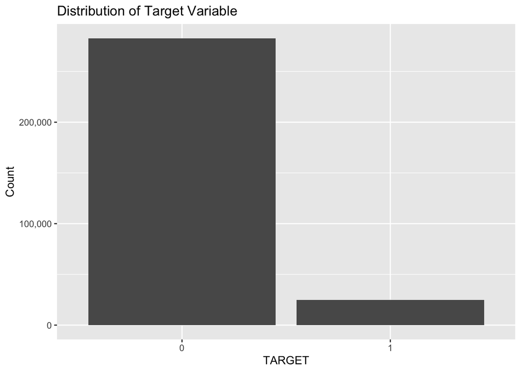

```r
# Distribution of TARGET variable
ggplot(train_HC, aes(x = as.factor(TARGET))) + geom_bar() +
  labs(title = "Distribution of Target Variable", x = "TARGET", y = "Count") +
  scale_y_continuous(labels = scales::comma)
```

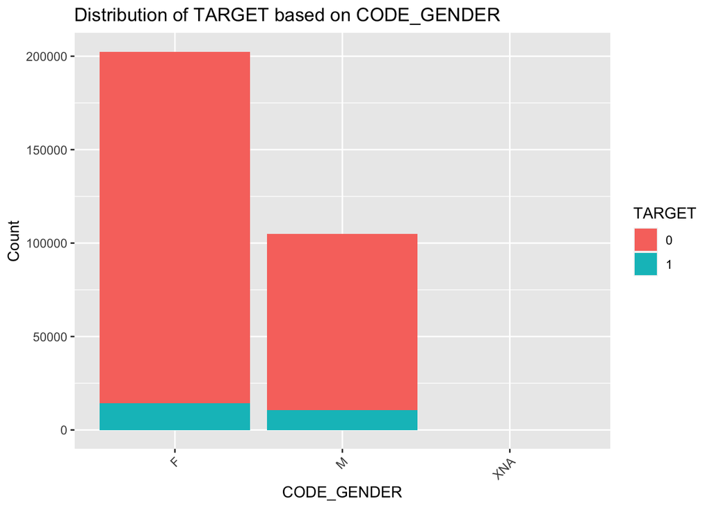

```r
# distribution of TARGET based on CODE_GENDER
ggplot(train_HC2, aes(x = CODE_GENDER, fill = factor(TARGET))) +
  geom_bar() +
  labs(title = "Distribution of TARGET based on CODE_GENDER",
       x = "CODE_GENDER",
       y = "Count",
       fill = "TARGET") +
  theme(axis.text.x = element_text(angle = 45, hjust = 1))   # Change colors as needed
```

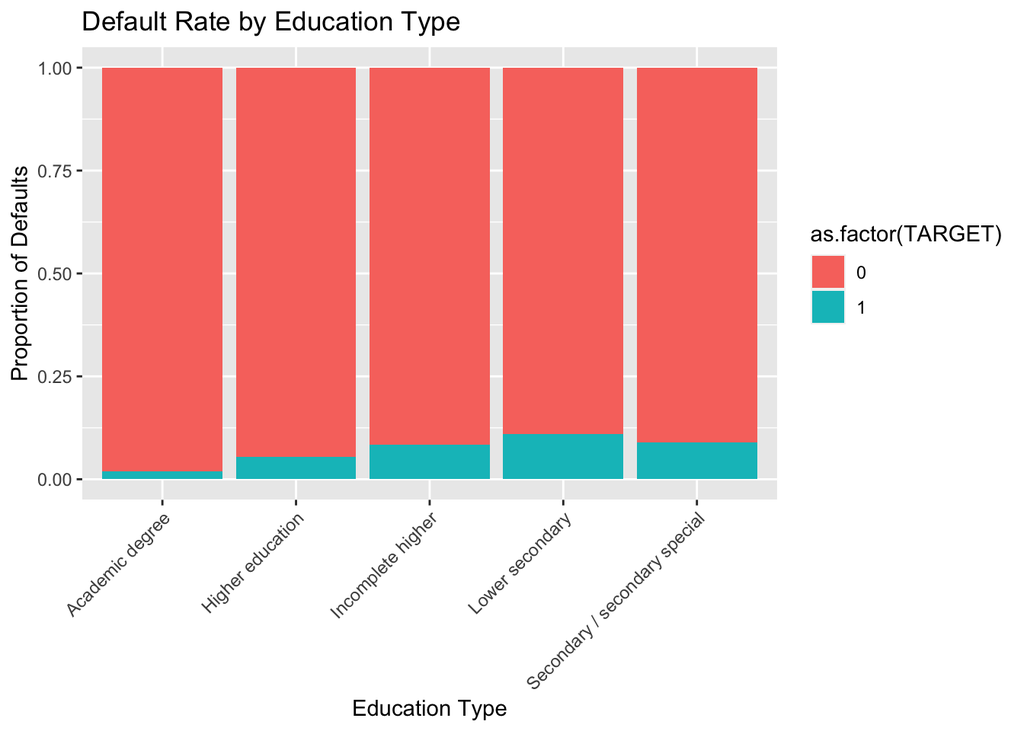

```r
# distribution of TARGET based on NAME_EDUCATION_TYPE
ggplot(train_HC2, aes(x = NAME_EDUCATION_TYPE, fill = as.factor(TARGET))) +
  geom_bar(position = "fill") +
  theme(axis.text.x = element_text(angle = 45, hjust = 1)) +
  labs(title = "Default Rate by Education Type", x = "Education Type", y = "Proportion of Defaults")
```

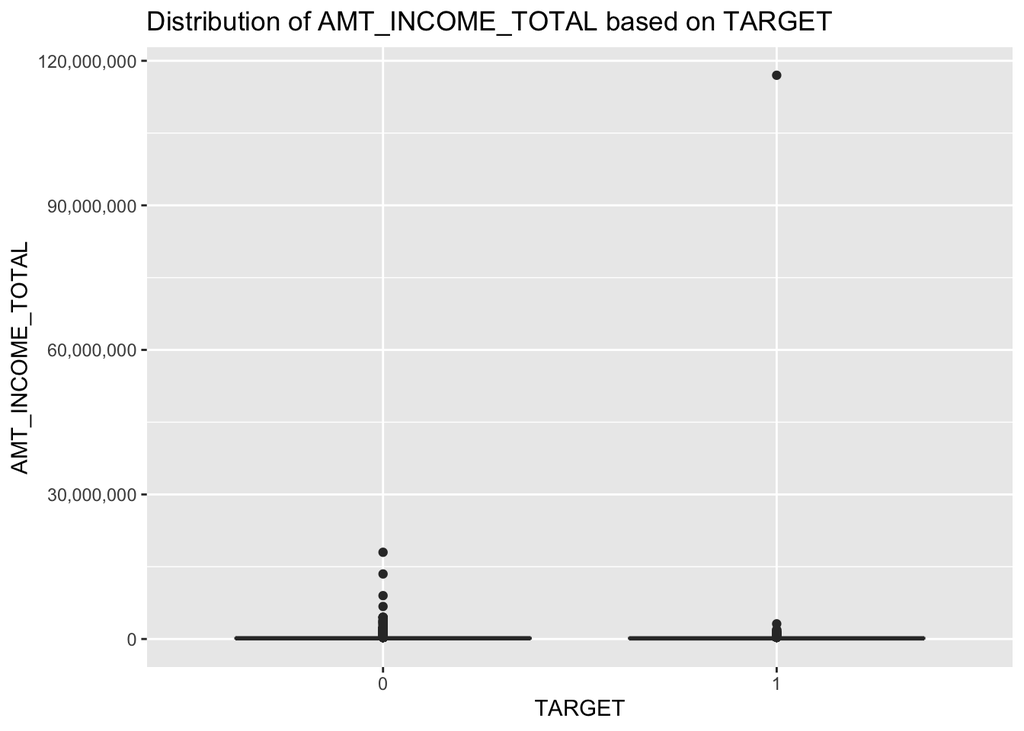

```r
# distribution of AMT_INCOME_TOTAL based on TARGET
ggplot(train_HC2, aes(x = factor(TARGET), y = AMT_INCOME_TOTAL)) +
  geom_boxplot() +
  labs(title = "Distribution of AMT_INCOME_TOTAL based on TARGET",
       x = "TARGET",
       y = "AMT_INCOME_TOTAL") +
  scale_y_continuous(labels = scales::comma)
```

Distribution of Target Variable:

This bar chart displays a significant imbalance between the two categories of the target variable. The category labeled ‘0’ has a much higher count than the category labeled ‘1’. Such an imbalance might indicate that the outcome ‘0’ occurs far more frequently than outcome ‘1’ in the dataset. This could be a case of a binary classification problem where one class is much more prevalent than the other, which is common in scenarios such as fraud detection, rare event prediction, etc.

Distribution of TARGET based on CODE_GENDER:

This bar chart differentiates the counts of the target variable by gender. The category ‘0’ of the target variable is predominant in both gender categories, but particularly so in the category labeled as ‘F’ for female. It suggests that for both genders, the outcome ‘0’ is more common, but the disparity between the outcomes ‘0’ and ‘1’ appears to be larger in the female category compared to the male category. This could imply gender-based differences in the dataset’s context, which might be worth investigating further.

Default Rate by Education Type:

## Merging new dataset

```r
bureau <- read_csv("bureau.csv")
head(bureau)
```

```
## # A tibble: 6 × 17
##   SK_ID_CURR SK_ID_BUREAU CREDIT_ACTIVE CREDIT_CURRENCY DAYS_CREDIT
##        <dbl>        <dbl> <chr>         <chr>                 <dbl>
## 1     215354      5714462 Closed        currency 1             -497
## 2     215354      5714463 Active        currency 1             -208
## 3     215354      5714464 Active        currency 1             -203
## 4     215354      5714465 Active        currency 1             -203
## 5     215354      5714466 Active        currency 1             -629
## 6     215354      5714467 Active        currency 1             -273
## # ℹ 12 more variables: CREDIT_DAY_OVERDUE <dbl>, DAYS_CREDIT_ENDDATE <dbl>,
## #   DAYS_ENDDATE_FACT <dbl>, AMT_CREDIT_MAX_OVERDUE <dbl>,
## #   CNT_CREDIT_PROLONG <dbl>, AMT_CREDIT_SUM <dbl>, AMT_CREDIT_SUM_DEBT <dbl>,
## #   AMT_CREDIT_SUM_LIMIT <dbl>, AMT_CREDIT_SUM_OVERDUE <dbl>,
## #   CREDIT_TYPE <chr>, DAYS_CREDIT_UPDATE <dbl>, AMT_ANNUITY <dbl>
```

```r
# shape of the dataset
num_rows <- nrow(bureau)
num_cols <- ncol(bureau)

print(num_rows)  # Number of rows
```

```
## [1] 1716428
```

```r
print(num_cols)  # Number of columns
```

```
## [1] 17
```

```r
summary(bureau)
```

```
##    SK_ID_CURR      SK_ID_BUREAU     CREDIT_ACTIVE      CREDIT_CURRENCY
##  Min.   :100001   Min.   :5000000   Length:1716428     Length:1716428
##  1st Qu.:188867   1st Qu.:5463954   Class :character   Class :character
##  Median :278055   Median :5926304   Mode  :character   Mode  :character
##  Mean   :278215   Mean   :5924434
##  3rd Qu.:367426   3rd Qu.:6385681
##  Max.   :456255   Max.   :6843457
##
##   DAYS_CREDIT    CREDIT_DAY_OVERDUE  DAYS_CREDIT_ENDDATE DAYS_ENDDATE_FACT
##  Min.   :-2922   Min.   :   0.0000   Min.   :-42060.0    Min.   :-42023
##  1st Qu.:-1666   1st Qu.:   0.0000   1st Qu.: -1138.0    1st Qu.: -1489
##  Median : -987   Median :   0.0000   Median :  -330.0    Median :  -897
##  Mean   :-1142   Mean   :   0.8182   Mean   :   510.5    Mean   : -1017
##  3rd Qu.: -474   3rd Qu.:   0.0000   3rd Qu.:   474.0    3rd Qu.:  -425
##  Max.   :    0   Max.   :2792.0000   Max.   : 31199.0    Max.   :     0
##                                      NA's   :105553      NA's   :633653
##  AMT_CREDIT_MAX_OVERDUE CNT_CREDIT_PROLONG AMT_CREDIT_SUM
##  Min.   :        0      Min.   :0.00000    Min.   :        0
##  1st Qu.:        0      1st Qu.:0.00000    1st Qu.:    51300
##  Median :        0      Median :0.00000    Median :   125518
##  Mean   :     3825      Mean   :0.00641    Mean   :   354995
##  3rd Qu.:        0      3rd Qu.:0.00000    3rd Qu.:   315000
##  Max.   :115987185      Max.   :9.00000    Max.   :585000000
##  NA's   :1124488                           NA's   :13
##  AMT_CREDIT_SUM_DEBT AMT_CREDIT_SUM_LIMIT AMT_CREDIT_SUM_OVERDUE
##  Min.   : -4705600   Min.   :-586406      Min.   :      0
##  1st Qu.:        0   1st Qu.:      0      1st Qu.:      0
##  Median :        0   Median :      0      Median :      0
##  Mean   :   137085   Mean   :   6230      Mean   :     38
##  3rd Qu.:    40154   3rd Qu.:      0      3rd Qu.:      0
##  Max.   :170100000   Max.   :4705600      Max.   :3756681
##  NA's   :257669      NA's   :591780
##  CREDIT_TYPE        DAYS_CREDIT_UPDATE  AMT_ANNUITY
##  Length:1716428     Min.   :-41947.0   Min.   :        0
##  Class :character   1st Qu.:  -908.0   1st Qu.:        0
##  Mode  :character   Median :  -395.0   Median :        0
##                     Mean   :  -593.8   Mean   :    15713
##                     3rd Qu.:   -33.0   3rd Qu.:    13500
##                     Max.   :   372.0   Max.   :118453424
##                                        NA's   :1226791
```

```r
# Read application_train data
application_train <- read.csv("application_train.csv")

# Read bureau data
bureau <- read.csv("bureau.csv")

# Merge the two datasets based on a common key
merged_data <- inner_join(application_train, bureau, by = "SK_ID_CURR")

head(merged_data)
```

```
##   SK_ID_CURR TARGET NAME_CONTRACT_TYPE CODE_GENDER FLAG_OWN_CAR FLAG_OWN_REALTY
## 1     100002      1         Cash loans           M            N               Y
## 2     100002      1         Cash loans           M            N               Y
## 3     100002      1         Cash loans           M            N               Y
## 4     100002      1         Cash loans           M            N               Y
## 5     100002      1         Cash loans           M            N               Y
## 6     100002      1         Cash loans           M            N               Y
##   CNT_CHILDREN AMT_INCOME_TOTAL AMT_CREDIT AMT_ANNUITY.x AMT_GOODS_PRICE
## 1            0           202500   406597.5       24700.5          351000
## 2            0           202500   406597.5       24700.5          351000
## 3            0           202500   406597.5       24700.5          351000
## 4            0           202500   406597.5       24700.5          351000
## 5            0           202500   406597.5       24700.5          351000
## 6            0           202500   406597.5       24700.5          351000
##   NAME_TYPE_SUITE NAME_INCOME_TYPE           NAME_EDUCATION_TYPE
```

[output cut: 244 more lines]

```r
# shape of the dataset
num_rows <- nrow(merged_data)
num_cols <- ncol(merged_data)

print(num_rows)  # Number of rows
```

```
## [1] 1465325
```

```r
print(num_cols)  # Number of columns
```

```
## [1] 138
```

```r
summary(merged_data)
```

```
##    SK_ID_CURR         TARGET        NAME_CONTRACT_TYPE CODE_GENDER
##  Min.   :100002   Min.   :0.00000   Length:1465325     Length:1465325
##  1st Qu.:188970   1st Qu.:0.00000   Class :character   Class :character
##  Median :278289   Median :0.00000   Mode  :character   Mode  :character
##  Mean   :278328   Mean   :0.07815
##  3rd Qu.:367494   3rd Qu.:0.00000
##  Max.   :456255   Max.   :1.00000
##
##  FLAG_OWN_CAR       FLAG_OWN_REALTY     CNT_CHILDREN     AMT_INCOME_TOTAL
##  Length:1465325     Length:1465325     Min.   : 0.0000   Min.   :    26100
##  Class :character   Class :character   1st Qu.: 0.0000   1st Qu.:   112500
##  Mode  :character   Mode  :character   Median : 0.0000   Median :   157500
##                                        Mean   : 0.4251   Mean   :   180637
##                                        3rd Qu.: 1.0000   3rd Qu.:   225000
##                                        Max.   :19.0000   Max.   :117000000
##
##    AMT_CREDIT      AMT_ANNUITY.x    AMT_GOODS_PRICE   NAME_TYPE_SUITE
##  Min.   :  45000   Min.   :  1616   Min.   :  40500   Length:1465325
##  1st Qu.: 284400   1st Qu.: 16875   1st Qu.: 247500   Class :character
##  Median : 538704   Median : 25348   Median : 454500   Mode  :character
##  Mean   : 623598   Mean   : 27448   Mean   : 561975
##  3rd Qu.: 835605   3rd Qu.: 35161   3rd Qu.: 711000
##  Max.   :4050000   Max.   :258026   Max.   :4050000
##                    NA's   :42       NA's   :1127
##  NAME_INCOME_TYPE   NAME_EDUCATION_TYPE NAME_FAMILY_STATUS NAME_HOUSING_TYPE
##  Length:1465325     Length:1465325      Length:1465325     Length:1465325
##  Class :character   Class :character    Class :character   Class :character
##  Mode  :character   Mode  :character    Mode  :character   Mode  :character
##
##
##
##
##  REGION_POPULATION_RELATIVE   DAYS_BIRTH     DAYS_EMPLOYED    DAYS_REGISTRATION
##  Min.   :0.00029            Min.   :-25201   Min.   :-17912   Min.   :-24672
##  1st Qu.:0.01001            1st Qu.:-19814   1st Qu.: -3201   1st Qu.: -7413
##  Median :0.01880            Median :-15971   Median : -1486   Median : -4493
##  Mean   :0.02038            Mean   :-16323   Mean   : 61734   Mean   : -4951
##  3rd Qu.:0.02639            3rd Qu.:-12938   3rd Qu.:  -361   3rd Qu.: -1969
##  Max.   :0.07251            Max.   : -7489   Max.   :365243   Max.   :     0
##
```

[output cut: 265 more lines]

```
##  Min.   :      0        Length:1465325     Min.   :-41947.0
##  1st Qu.:      0        Class :character   1st Qu.:  -904.0
##  Median :      0        Mode  :character   Median :  -406.0
##  Mean   :     40                           Mean   :  -599.8
##  3rd Qu.:      0                           3rd Qu.:   -33.0
##  Max.   :3756681                           Max.   :   372.0
##
##  AMT_ANNUITY.y
##  Min.   :       0
##  1st Qu.:       0
##  Median :      68
##  Mean   :   15763
##  3rd Qu.:   13990
##  Max.   :59586682
##  NA's   :1130013
```

```r
# Remove columns with more than 50% null values
threshold <- nrow(merged_data) * 0.5
merged_data <- merged_data[, colMeans(is.na(merged_data)) < 0.5]

# Correlations with target variable
if ("TARGET" %in% colnames(merged_data)) {
  # Select only numeric columns
  numeric_cols <- sapply(merged_data, is.numeric)

  # Exclude the 'TARGET' variable from numeric columns
  numeric_cols <- numeric_cols & colnames(merged_data) != "TARGET"

  # Compute the correlation between TARGET variable and all other numeric variables
  correlation_with_target <- cor(merged_data[, numeric_cols], merged_data$TARGET, use = "complete.obs")

  # Print the correlation with the target variable
  print(correlation_with_target)
} else {
  print("Target variable 'TARGET' not found in the dataset.")
}
```

```
##                                       [,1]
## SK_ID_CURR                    0.0015218894
## CNT_CHILDREN                  0.0131673943
## AMT_INCOME_TOTAL              0.0036920293
## AMT_CREDIT                   -0.0121243806
## AMT_ANNUITY.x                -0.0046705006
## AMT_GOODS_PRICE              -0.0204824291
## REGION_POPULATION_RELATIVE   -0.0175941306
## DAYS_BIRTH                    0.0615994831
## DAYS_EMPLOYED                -0.0296559407
## DAYS_REGISTRATION             0.0232470876
## DAYS_ID_PUBLISH               0.0368846529
## FLAG_MOBIL                              NA
## FLAG_EMP_PHONE                0.0306222703
## FLAG_WORK_PHONE               0.0117931382
## FLAG_CONT_MOBILE             -0.0002388829
## FLAG_PHONE                   -0.0194755612
## FLAG_EMAIL                    0.0070045800
## CNT_FAM_MEMBERS               0.0121760845
## REGION_RATING_CLIENT          0.0437428520
## REGION_RATING_CLIENT_W_CITY   0.0456972823
## HOUR_APPR_PROCESS_START      -0.0148244526
## REG_REGION_NOT_LIVE_REGION    0.0022207808
## REG_REGION_NOT_WORK_REGION   -0.0001163035
## LIVE_REGION_NOT_WORK_REGION  -0.0024343066
## REG_CITY_NOT_LIVE_CITY        0.0159271882
## REG_CITY_NOT_WORK_CITY        0.0164858366
## LIVE_CITY_NOT_WORK_CITY       0.0133912001
## EXT_SOURCE_2                 -0.1355450870
## EXT_SOURCE_3                 -0.1650279682
## APARTMENTS_AVG               -0.0165469575
## YEARS_BEGINEXPLUATATION_AVG  -0.0086941481
## ENTRANCES_AVG                -0.0155079400
## FLOORSMAX_AVG                -0.0331606436
## LIVINGAREA_AVG               -0.0203111256
## APARTMENTS_MODE              -0.0157097923
## YEARS_BEGINEXPLUATATION_MODE -0.0072168672
## ENTRANCES_MODE               -0.0143854029
## FLOORSMAX_MODE               -0.0325283874
## LIVINGAREA_MODE              -0.0187849714
```

[output cut: 33 more lines]

```
## AMT_REQ_CREDIT_BUREAU_WEEK    0.0023353577
## AMT_REQ_CREDIT_BUREAU_MON    -0.0165906592
## AMT_REQ_CREDIT_BUREAU_QRT     0.0062209075
## AMT_REQ_CREDIT_BUREAU_YEAR    0.0239151260
## SK_ID_BUREAU                 -0.0058301811
## DAYS_CREDIT                   0.0387524402
## CREDIT_DAY_OVERDUE            0.0037487597
## DAYS_CREDIT_ENDDATE           0.0016323455
## DAYS_ENDDATE_FACT             0.0346267337
## CNT_CREDIT_PROLONG            0.0009215389
## AMT_CREDIT_SUM               -0.0101875401
## AMT_CREDIT_SUM_DEBT           0.0002979225
## AMT_CREDIT_SUM_LIMIT          0.0019062375
## AMT_CREDIT_SUM_OVERDUE       -0.0006427622
## DAYS_CREDIT_UPDATE            0.0191153422
```

## Comparing application_train and merged data with correlations

Overall, while there are some differences in the correlation coefficients between the two datasets, the top predictors with positive and negative correlation remain largely consistent. These differences could be due to the inclusion of additional variables or different distributions in the merged dataset, which might affect the correlations with the target variable. Further analysis may be needed to understand the reasons behind these differences and their implications for modeling or analysis.